# Milk

#### Predykcja z wykorzystaniem biblioteki “itsmr”

We wcześniejszych krokach, ustaliliśmy wszystkie niezbędne parametry. Posługując się pakietem “itsmr” oraz zaproponowaną przez twórców metodą, przeprowadzimy predykcję.

```r
M = c("season",12,"trend",2)
# Powyższy model odejmuje składnik sezonowy z okresem 12, następnie odejmuje składnik trendu kwadratowego (ustalony sezon wyniósł 12, natomiast ustalony stopień wielomianu trendu wyniósł 2).
a = arma(res,1,0)
forecast1 <- itsmr::forecast(milk %>% as.numeric(),M,a,12,2)
```

```
##  Step     Prediction      sqrt(MSE)    Lower Bound    Upper Bound
##     1       1690.196       12.98094       1664.754       1715.639
##     2       1580.525       16.11441       1548.941       1612.108
##     3       1738.346       17.57844       1703.892       1772.799
##     4       1708.352       18.32185       1672.442       1744.263
##     5       1760.483       18.71177       1723.809       1797.158
##     6       1680.749       18.91938       1643.668        1717.83
##     7       1677.896       19.03076       1640.596       1715.195
##     8       1652.926       19.09076       1615.508       1690.343
##     9       1596.344       19.12314       1558.863       1633.824
##    10       1641.196       19.14064       1603.681       1678.711
##    11       1597.496        19.1501       1559.962       1635.029
##    12       1667.454       19.15521       1629.911       1704.998
```

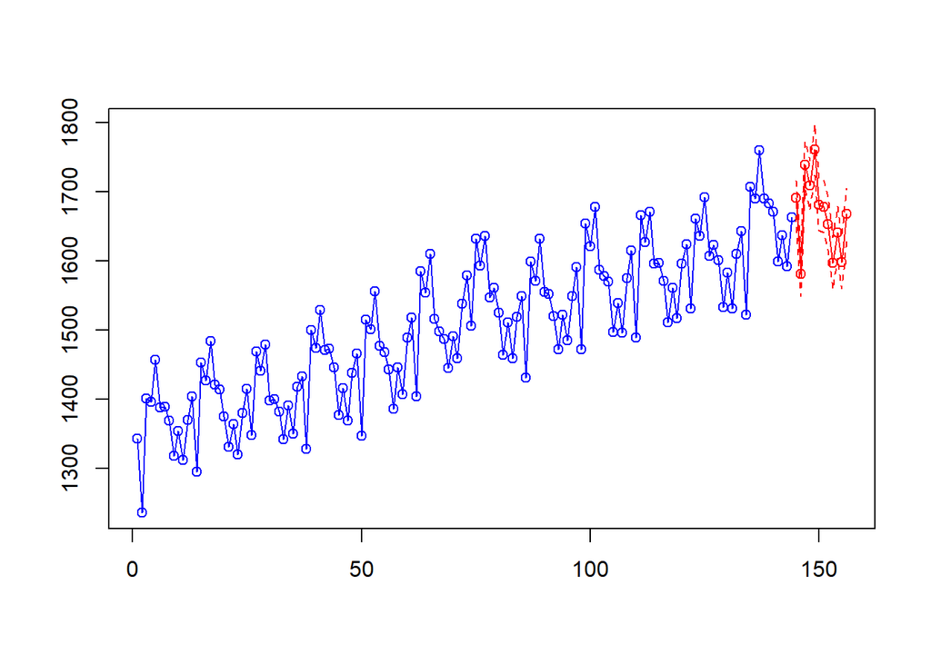

```r
# Funckja forecast() wymaga, aby wprowadzić kolejno:
# x= zbiór danych w postaci numerycznej (milk %>% as.numeric()- konwertuje szereg czasowy w wektor numeryczny)
# M= model danych- określenie długości sezonu, postaci trendu+ ewentualne przekształcenia danych, np. z wykorzystaniem log()
# a= model arma()
# h= ilość okresów do przewidzenia
```

Wskaźniki dopasowania policzymy dla predykcji przy podziale danych na treningowe i testowe.

Dodatkowe porównanie metodą graficzną, przy pominięciu ostatniego roku w oryginalnych danych.

```
## Wykorzystamy wbudowaną metodę z biblioteki itsmr, do uzyskiwania reszt, tj. funkcję Resid().
```

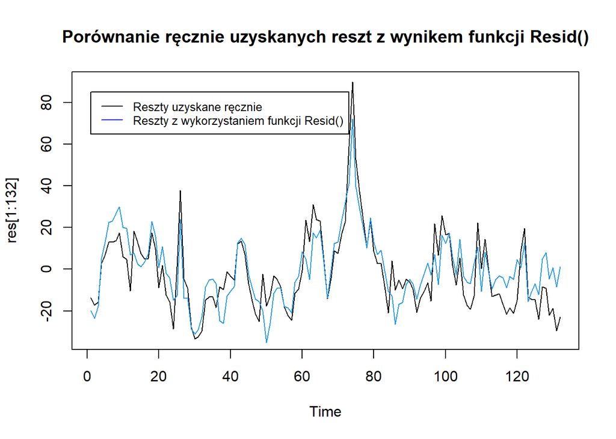

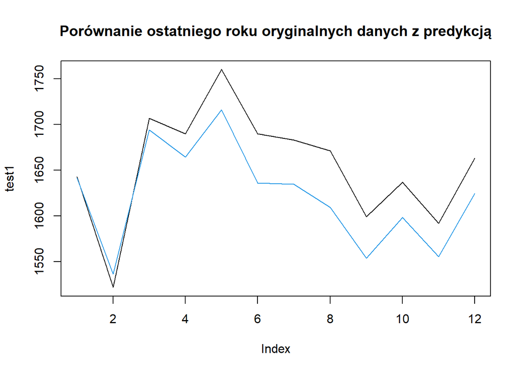

Wyraźnie widzimy, że prognoza kieruję się ku dołu. Dzieje się tak za sprawą wybranego trendu. W przypadku wyboru trendu jako np. wielomianu stopnia 5-tego, który ma tendencję do wzrostu, prognoza zaczyna kierować się ku górze.

Zanim jednak przejdziemy do porównania graficznego, sprawdźmy otrzymane dopasowanie predykcji.

```
## ME:     32.69889
```

```
## MSE:    1527.017
```

```
## RMSE:   39.07706
```

```
## MAE:    35.07983
```

```
## MPE:    2.111872
```

```
## MAPE:   2.111872
```

```
## MASE:   1.217697
```

```
## RMSSE:  1.123444
```

Dopasowanie prognozy po zmianie trendu.

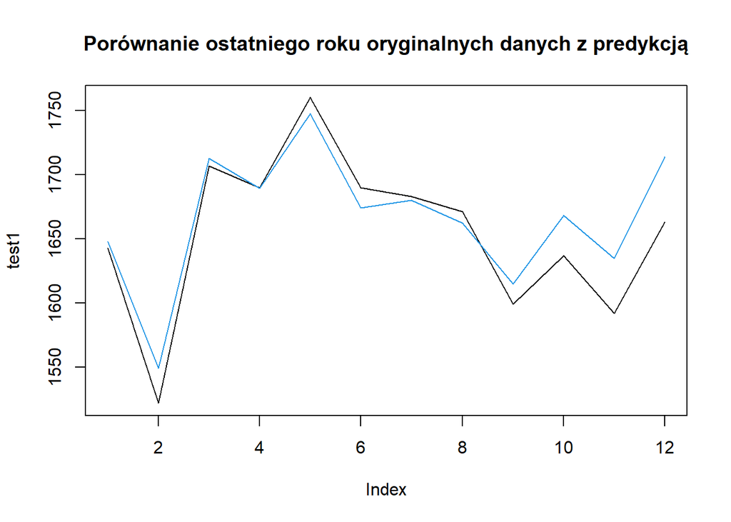

Możemy zaobserwować, że współczynniki dopasowania predykcji, faktycznie uległy poprawie.

```
## ME:     14.27235
```

```
## MSE:    205.2325
```

```
## RMSE:   14.32594
```

```
## MAE:    14.27235
```

```
## MPE:    0.8629585
```

```
## MAPE:   0.8629585
```

```
## MASE:   0.4954243
```

```
## RMSSE:  0.411863
```

Natomiast nie wolno się tym bezwględnie sugerować. Dopasowanie trendu do predykcji powinno być popratę wiedzą eksperta, który już zna pewne zachowania rynku i byłby w stanie określić, który trend byłby optymalny. My możemy tylko zaproponować kilka modeli o jak najlepszym dopasowaniu.

### Wykorzystanie pakietu “fpp3”

W dalszej części, wypróbujemy metodę zaproponowaną przez Rob’a Hyndman’a, który do konstrukcji modelu ARIMA() wykorzystuje funkcje z bilbiotek “fable” oraz “tsibble”, które są zawarte w bilbiotece “fpp3”.

#### Model spaceru losowego, czyli alternatywne podejście do sezonowości

Szereg różnicowy jest zmianą pomiędzy kolejnymi obserwacjami w szeregu pierwotnym i może być zapisany jako $y'_t=y_t-y_{t-1}$. Gdy szereg różnicowany jest białym szumem, model dla szeregu pierwotnego można zapisać jako $y_t-y_{t-1} = \varepsilon_t$ gdzie $\varepsilon_t$ oznacza biały szum. Po prostym przekształceniu, otrzymujemy model spaceru losowego: $y_t= y_{t-1}+\varepsilon_t$.

Czasami zróżnicowane dane nie wydają się być stacjonarne i może być konieczne, aby zróżnicować dane po raz drugi, aby uzyskać stacjonarny szereg:
$$y''_t= y'_t-y'_{t-1}=(y_t-y_{t-1})-(y_{t-1}-y_{t-2})=y_t-2y_{t-1}+y_{t-2}$$
Dla dyskretnego szeregu czasowego różnica drugiego rzędu reprezentuje krzywiznę szeregu w danym punkcie czasowym. Jeśli różnica drugiego rzędu jest dodatnia, to szereg czasowy jest zakrzywiony w górę w tym czasie, a jeśli jest ujemna, to szereg czasowy jest zakrzywiony w dół w tym czasie (analogia z drugą pochodną).

Podobnie postepuję się w przypadku różnicowania sezonowego, które jest różnicą między obserwacją a poprzednią obserwacją z tego samego sezonu. Niech $m \in \mathbb{N}$ będzie m-tym sezonem. Wówczas sezonowy szereg różnicowy jest postaci: $y'_t=y_t-y_{t-m}$. Przy czym, jeżeli jest on białym szumem, to otrzymujemy model postaci $y_t= y_{t-m}+\varepsilon_t$.

Różnice pierwszego stopnia są zmianą pomiędzy jedną obserwacją a drugą. Różnice sezonowe to zmiana między jednym rokiem a drugim. Inne opóźnienia najprawdopodobniej nie będą miały większego sensu interpretacyjnego i należy ich unikać.

Sprawdźmy to na zbiorze milk, w którym sezonowość jest równa 12. Do przeprowadzenia różnicowania, skorzystamy z funkcji difference() (z pakietu tsibble).

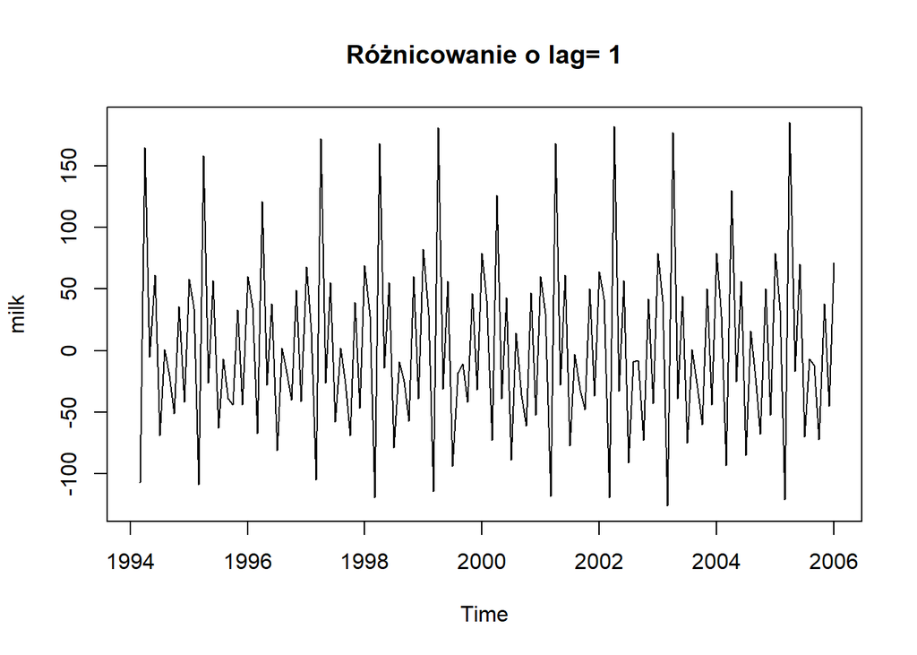

```
## Brak oczekiwanego skutku
```

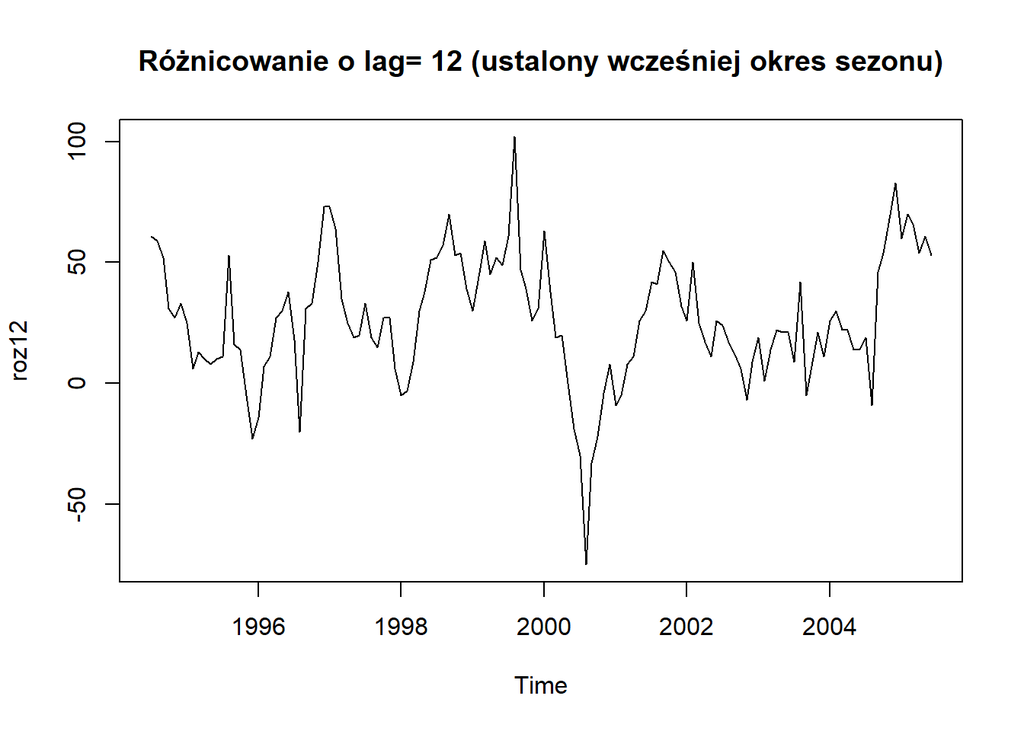

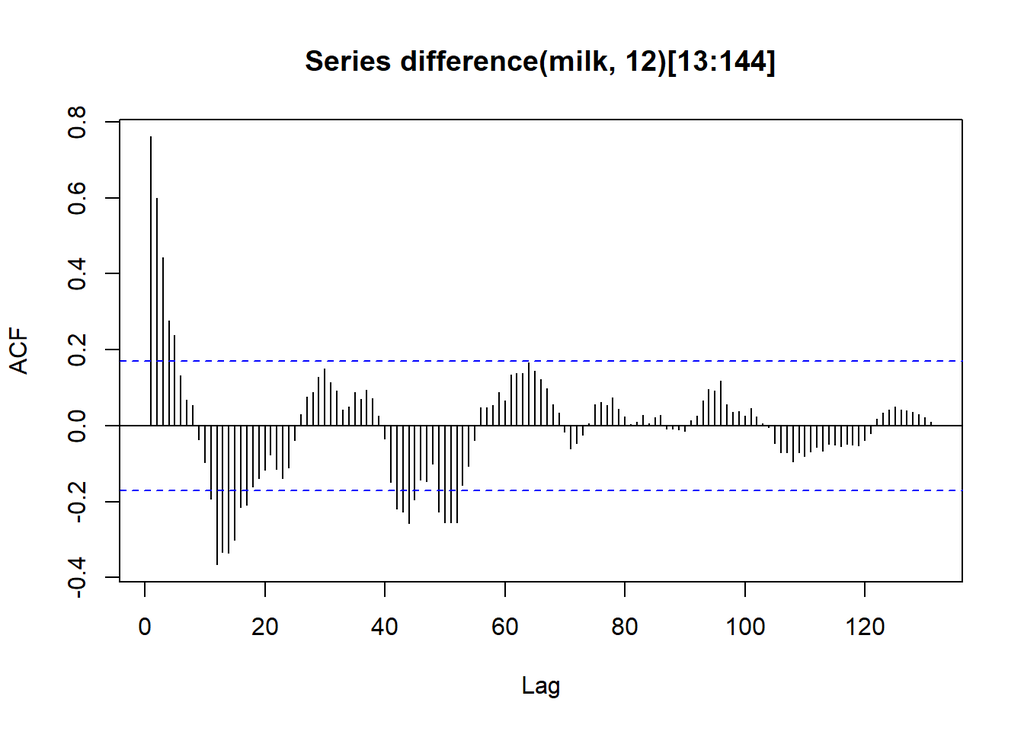

```
## Sukces! Udało się nam otrzymać szereg stacjonarny.
## Potwierdza to ustalony okres sezonowości równy 12.
```

Uwaga! Należy pamiętać, że zastosowanie większej liczby różnic niż wymagana spowoduje fałszywą dynamikę lub autokorelacje, które w rzeczywistości nie istnieją w szeregu czasowym. Dlatego wykonujemy tak mało różnic, jak to konieczne, aby uzyskać szereg stacjonarny.

#### Działanie funkcji ARIMA() oraz budowanie niesezonowego modelu

Funkcja ARIMA() z biblioteki “fable” wykorzystuje wariacje algorytmu Hyndman-Khandakar, który łączy w sobie test KPSS wraz z minimalizacją AICc i MLE, aby uzyskać model ARIMA. Dla zainteresowanych, w książce Hyndman-a, w rozdziale 9.7 “ARIMA modelling in fable”, autor graficznie przedstawił schemat działania tegoż algorytmu.

Podczas dopasowywania modelu ARIMA do (niesezonowego) szeregu czasowego, klasycznym podejściem jest:

1. Narysowanie wykresu i identyfikacja nietypowych obserwacji.
2. Jeżeli konieczna, transformacja danych dla ustabilizowania wariancji (transoframcja Box’a-Cox’a).
3. Jeżeli szereg jest niestacjonarny, to identyfikacja sezonowości lub pierwsze różnicowanie danych (oba do momentu uzyskania szeregu stacjonarnego).
4. Badanie wykresów ACF/PACF w celu stwierdzenia jaki model będzie odpowiedni (ARIMA(p,d,0) lub ARIMA(0,d,q)).
5. Próba dobrania najlepszego modelu pod względem minimalizacji AICc.
6. Sprawdzenie residuów z wybranego modelu poprzez narysowanie wykresu ACF.
7. Prognoza, pod warunkiem, że residua przypominają biały szum.

Algorytm Hyndman-Khandakar automatyzuje kroki 3-5. Wykorzystajmy tą metodę dla zbioru “milk”. Oczywiście, żadna transformacja danych nie jest wymagana.

W pierwszej kolejności konwertujemy dane do postaci akceptowalnej przez funkcję ARIMA(). Następnie wskazujemy kolumnę ze zmiennymi losowymi: “as_tsibble(res) %>% model(ARIMA(value ~ pdq(p=0:4, d=0:2, q=0:4)+ PDQ(0,0,0)))”

```
## Series: value
## Model: ARIMA(1,0,0)
##
## Coefficients:
##          ar1
##       0.7356
## s.e.  0.0556
##
## sigma^2 estimated as 169.7:  log likelihood=-573.86
## AIC=1151.72   AICc=1151.8   BIC=1157.66
```

Otrzymaliśmy model ARIMA(1,0,0), tj. Autoregresję dla p= 1. Spróbujemy uzyskać lepszy model poprzez dezaktywację zmiennych optymalizująych działanie funkcji, tj.: greedy = F; odpowiadające za wyłączenie natychmiastowego “przeskakiwania” do modeli uzyskujących lepszy wynik, approximation = F; odpowiadające za wyłączenie stosowania przybliżeń wyników, stepwise = F; odpowiadające za włączenie sprawdzania wszystkich możliwych kombinacji. Oczywiście musimy liczyć się ze znacznym spowolnieniem działania.

```
## Series: value
## Model: ARIMA(1,0,0)
##
## Coefficients:
##          ar1
##       0.7356
## s.e.  0.0556
##
## sigma^2 estimated as 169.7:  log likelihood=-573.86
## AIC=1151.72   AICc=1151.8   BIC=1157.66
```

Dużą korzyścią dla analityków jest możliwość wywoływania kilku modeli jednoczeście wraz z porównaniem ich wyników. Pakiet “fpp3”, a dokładniej funkcja glance() z pakietu "fabletools, która wykorzystuje modele w obrębie mable do utworzenia jednowierszowego podsumowania ich dopasowania, umożliwia nam takie porównanie.

```
## # A tibble: 10 x 8
##    .model                  sigma2 log_lik   AIC  AICc   BIC ar_roots  ma_roots
##    <chr>                    <dbl>   <dbl> <dbl> <dbl> <dbl> <list>    <list>
##  1 auto_ARIMA_optymalna      170.   -574. 1152. 1152. 1158. <cpl [1]> <cpl [0]>
##  2 auto_ARIMA_nieoptymalna   170.   -574. 1152. 1152. 1158. <cpl [1]> <cpl [0]>
##  3 auto_ARIMA_1_0_0          170.   -574. 1152. 1152. 1158. <cpl [1]> <cpl [0]>
##  4 auto_ARIMA_0_0_1          227.   -595. 1194. 1194. 1199. <cpl [0]> <cpl [1]>
##  5 auto_ARIMA_1_0_1          171.   -574. 1154. 1154. 1163. <cpl [1]> <cpl [1]>
##  6 auto_ARIMA_2_0_0          171.   -574. 1154. 1154. 1163. <cpl [2]> <cpl [0]>
##  7 auto_ARIMA_0_0_2          190.   -581. 1169. 1169. 1177. <cpl [0]> <cpl [2]>
##  8 auto_ARIMA_2_0_1          172.   -574. 1155. 1156. 1167. <cpl [2]> <cpl [1]>
##  9 auto_ARIMA_1_0_2          170.   -573. 1154. 1154. 1166. <cpl [1]> <cpl [2]>
## 10 auto_ARIMA_2_0_2          171.   -573. 1156. 1156. 1170. <cpl [2]> <cpl [2]>
```

Z powyższej tabeli można stwierdzić, że model ARIMA(1,0,0) był lepiej dopasowany. Następnie wykorzystamy wbudowaną funkcję gg_tsresiduals() do wydobycia i zbadania uzyskanych z modelu reszt.

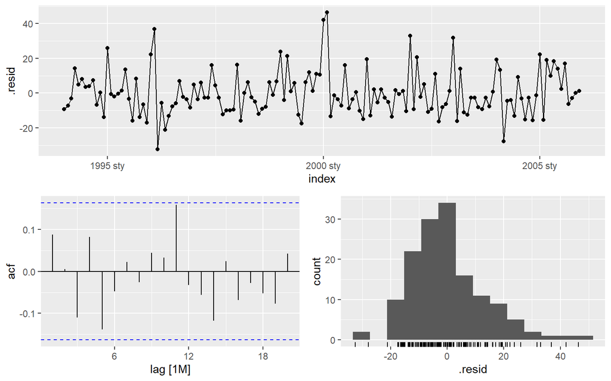

Możemy również wydobyć wartości residuów ręcznie poprzez funkcję stats::residuals(), co pozwoli nam na własnoręczne sprawdzenie uzyskanych reszt.

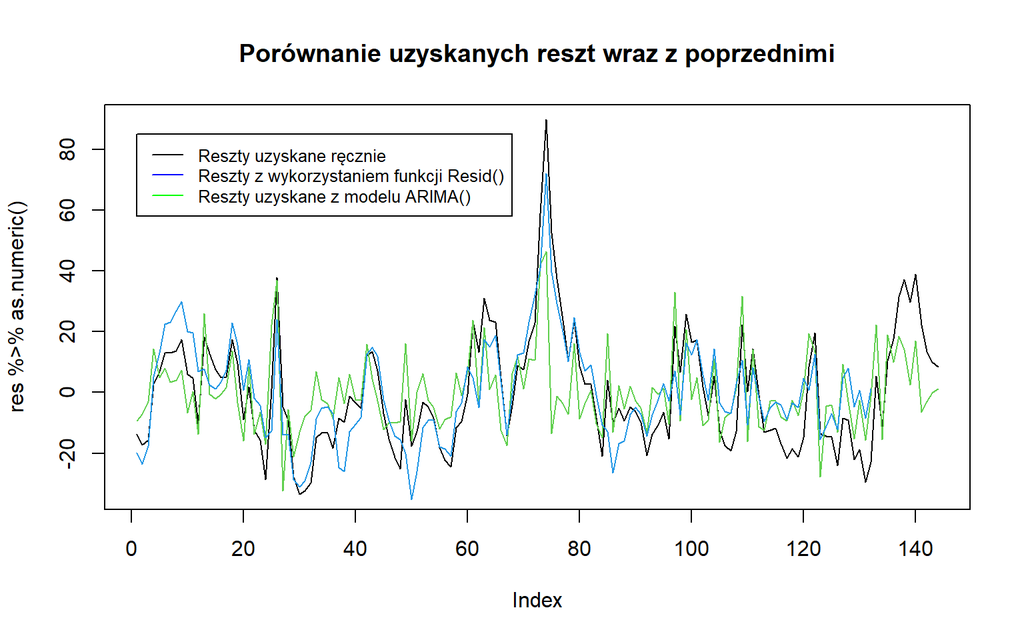

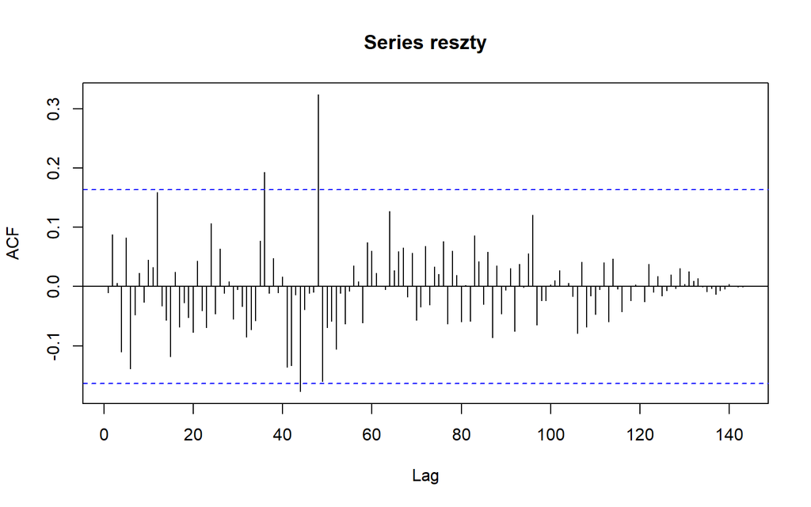

```
##
##  Box-Pierce test
##
## data:  reszty
## X-squared = 0.01465, df = 1, p-value = 0.9037
```

Dodatkowo, możemy sprawdzić dopasowanie uzyskanego modelu, wykorzystując funkcję fitted() z pakietu “stats”.

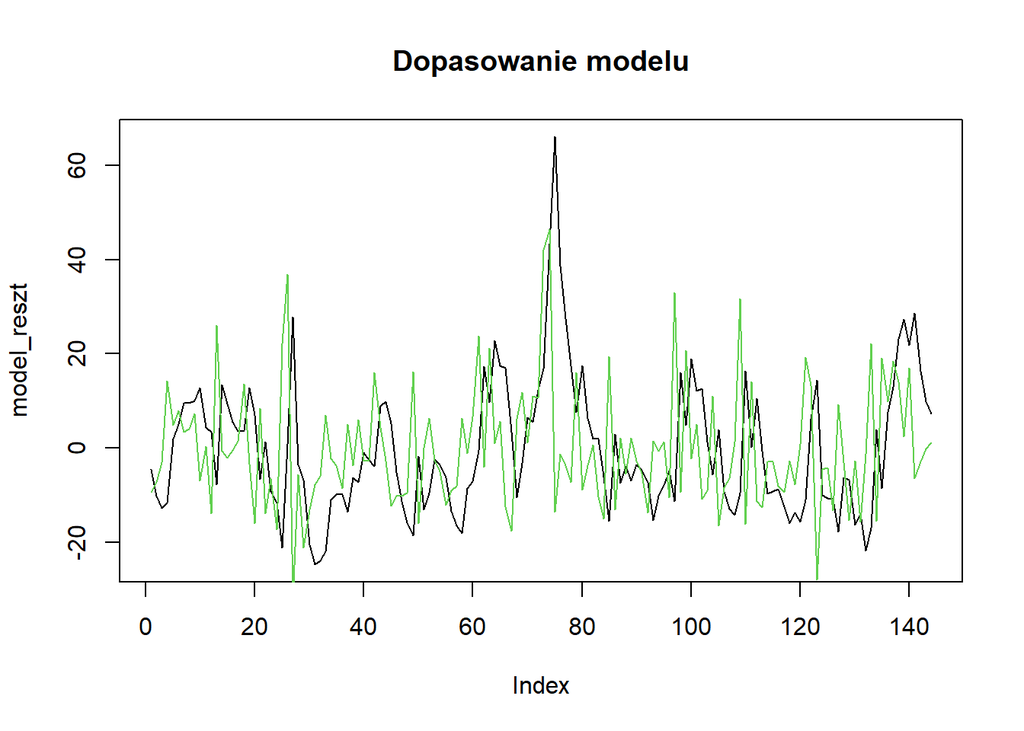

Zatem możemy przejść do predykcji. W tym celu wykorzsytamy funckję forecast() z pakietu “fable”. Ta funkcja prognozy umożliwia tworzenie przyszłych przewidywań szeregu czasowego na podstawie dopasowanych modeli. Jeśli zmienna zalezna od odpowiedzi została przekształcona w formułe modelu, przekształcenie to zostanie automatycznie przekształcone wstecz. Wszystkie modele Fable z opartą na formułach specyfikacją modelu wspierają wysoce elastyczną specyfikację transformacji. Określone transformacje są automatycznie przekształcane wstecznie i korygowane pod kątem błędu systematycznego w celu uzyskania prognozowanych średnich i dopasowanych wartości w oryginalnej skali danych. (https://robjhyndman.com/hyndsight/backtransforming/)

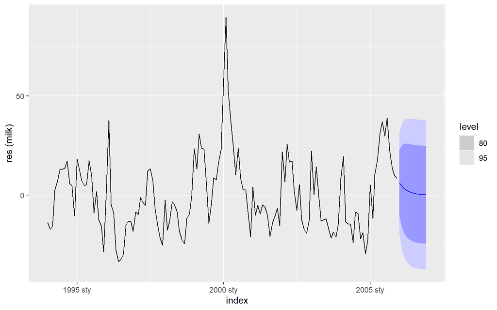

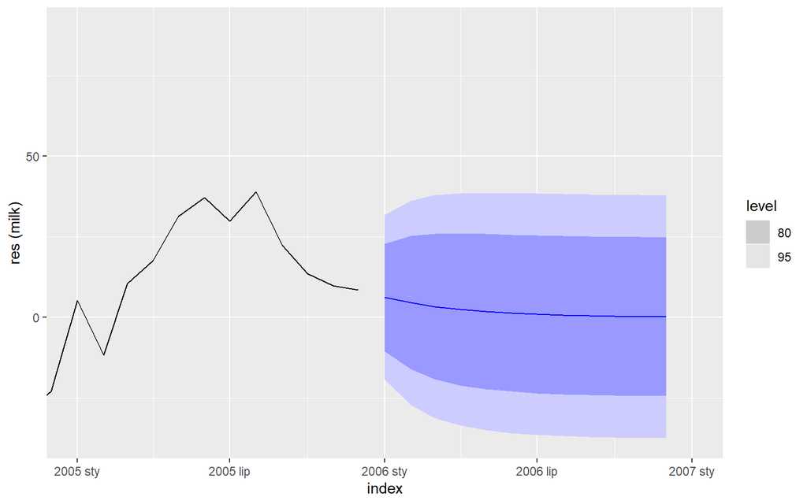

Domyślnie, funkcja ARIMA() automatycznie określam czy stała jest wymagana. Dla d= 0 lub d= 1, stała zostanie uwzględniona, jeśli poprawi to wartość AICc. Jeżeli $d > 1$ stała jest zawsze pomijana, ponieważ trend kwadratowy lub wyższego rzędu jest szczególnie niebezpieczny przy prognozowaniu. Oczywiście możemy zmusić model do uwzględnienia bądź zignorowania stałej.

```
## ARIMA(value ~ 1 + ... ,gdzie 1 oznacza wymuszenie uwzględnienia stałej
```

```
## Series: value
## Model: ARIMA(1,0,0) w/ mean
##
## Coefficients:
##          ar1  constant
##       0.7356   -0.0260
## s.e.  0.0556    1.0615
##
## sigma^2 estimated as 170.9:  log likelihood=-573.86
## AIC=1153.72   AICc=1153.89   BIC=1162.62
```

```
## ARIMA(value ~ 0 + ... ,gdzie 0 oznacza wymuszenie zignorowania stałej
```

```
## Series: value
## Model: ARIMA(1,0,0)
##
## Coefficients:
##          ar1
##       0.7356
## s.e.  0.0556
##
## sigma^2 estimated as 169.7:  log likelihood=-573.86
## AIC=1151.72   AICc=1151.8   BIC=1157.66
```

Uwaga! Przedziały ufności dla modeli ARIMA opierają się na założeniu, że reszty są nieskorelowane i mają rozkład normalny. Jeżeli którekolwiek z tych założeń nie jest spełnione, wówczas przedziały predykcji mogą być nieprawidłowe. Z tego powodu, zawsze należy sporządzić wykres ACF i histogram reszt w celu sprawdzenia założeń przed sporządzeniem przedziałów ufności.

Jeżeli reszty są nieskorelowane, ale nie mają rozkładu normalnego, to zamiast tego można zastosować Bootstrap (wprowadzone przez Bradleya Efrona metody szacowania rozkładu błędów estymacji, za pomocą wielokrotnego losowania ze zwracaniem z próby. Są przydatne szczególnie, gdy nie jest znana postać rozkładu zmiennej w populacji). Wystarczy do funkcji forecast() dodać “bootstrap=TRUE”.

Uzyskaliśmy predykcję, lecz dotyczy ona szeregu stacjonarnego reszt. Aby uzyskać predykcję dla wraz z naniesionym trendem oraz sezonowością, proponuje się wykorzystanie powyżej metody dla całych danych wraz z ewentualnym uprzednim zidentyfikowaniem parametrów modelu.

#### Sezonowy model ARIMA()

W sezonowym modelu ARIMA stosuje się dodatkowo zmienna P,D,Q, dla modelu sezonowego $ARIMA(p,d,q)(P,D,Q)_m$, gdzie $m$ jest liczbą indeksów na sezon (długość sezonu), $(p,d,q)$ jest niesezonową częścią modelu, a $(P,D,Q)$ jest sezonową częścią modelu.

Przykładowy model $ARIMA(1,1,1)(1,1,1)_4$ bez stałej, jest postaci:
$$(1-\phi_1B)(1-\Phi_1B^4)(1-B)(1-B^4)y_t=(1+\theta_1B)(1+\Theta_1B^4)\varepsilon_t$$
gdzie:

1. $(1-B^4)$ to różnice sezonowe,
2. $(1-B)$ to różnice niesezonowe,
3. $(1-\Phi_1B^4)$ to sezonowy model $AR(1)$,
4. $(1-\phi_1B)$ to niesezonowy model $AR(1)$,
5. $(1+\Theta_1B^4)$ to sezonowy model $MA(1)$,
6. $(1+\theta_1B)$ to niesezonowy model $MA(1)$.

Wszystkie czynniki można pomnożyć, a ogólny model zapisać w następujący sposób:

$y_t=$ $=(1+\phi_1)y_{t-1}-\phi_1y_{t-2}+(1+\Phi_1)y_{t-4}-(1+\phi_1+\Phi_1+\phi_1\Phi_1)y_{t-5}+(\phi_1+\phi_1\Phi_1)y_{t-6}-\Phi_1y_{t-8}+(\Phi_1+\phi_1\Phi_1)y_{t-9}-\phi_1\Phi_1y_{t-10}+$ $+\varepsilon_t+\theta_1\varepsilon_{t-1}+\Theta_1\varepsilon_{t-4}+\theta_1\Theta_1\varepsilon_{t-5}$

W celu wstępnego dobrania współczynników, można wykorzystać funkcje acf() i pacf(). W tym celu stosuje się metodę różnicowania z wykorzystaniem funkcji difference(). Nastepnie analizuje się znaczne wielkości na obu wykresach. Niestety, dla osób dopiero poznających zagadnienie szeregów czasowych (takimi jak ja), może to być zadanie trudne, aby pewnie wskazać odpowiednie parametry. Szczęśliwie, sezonowa wersja modelu ARIMA, podobnie jak w przypadku niesezonowego modelu, ma wbudowany algorytm do automatycznego wskazywania najlepszych współczynników.

```r
fit <- as_tsibble(milk) %>% model(ARIMA(value ~ pdq(p=0:4, d=0:2, q=0:4)+ PDQ(P=0:4, D=0:2, Q=0:4)))
report(fit)
```

```
## Series: value
## Model: ARIMA(1,0,0)(3,1,0)[12] w/ drift
##
## Coefficients:
##          ar1     sar1     sar2     sar3  constant
##       0.8845  -0.9064  -0.8038  -0.5833   10.0230
## s.e.  0.0424   0.0712   0.0796   0.0718    0.9983
##
## sigma^2 estimated as 119.5:  log likelihood=-512.13
## AIC=1036.26   AICc=1036.93   BIC=1053.56
```

Widzimy, że zaproponowana struktura modelu ARIMA, to niesezonowy model AR(1) wraz z sezonowym modelem AR(3), przy jednokrotnym zróżnicowaniu sezonowym danych o 12. Uzyskany model ARIMA wykazuje AICc= 1036.93 < 1151.801 (model itsmr::arma()). Porównajmy uzyskany model z oryginalnymi danymi:

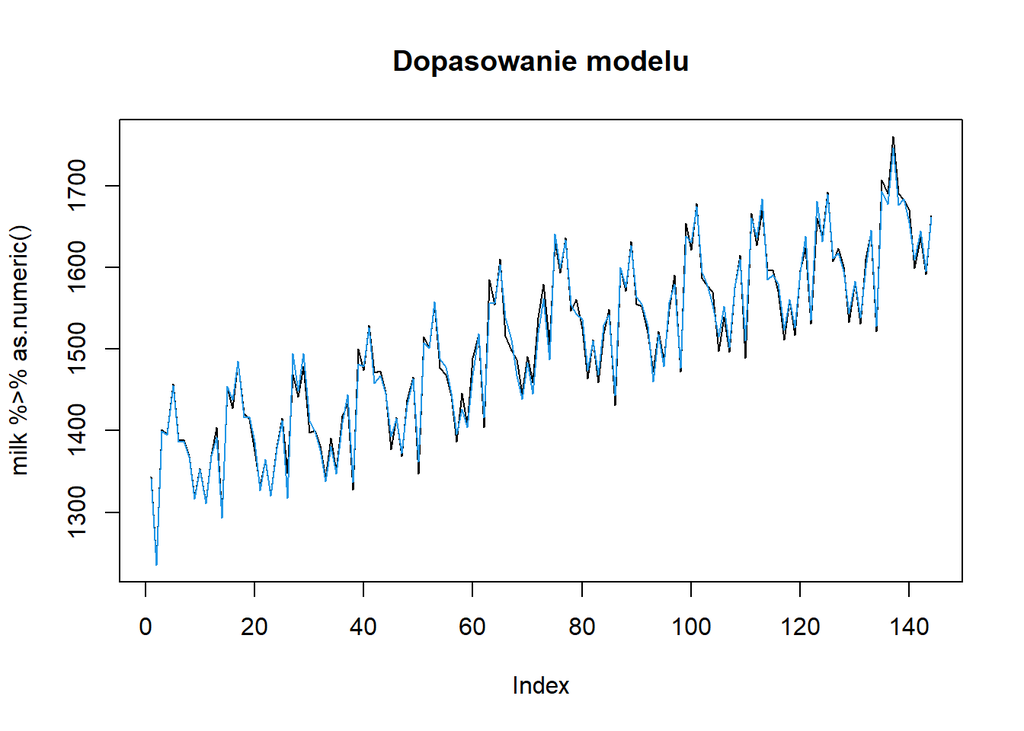

```
## Oczywiście, w wyniku różnicowania o sezon, utraciliśmy początkowe 12 wartości.
```

Wydobądźmy resztki z otrzymanego modelu oraz je przetestujmy pod kątem białego szumu.

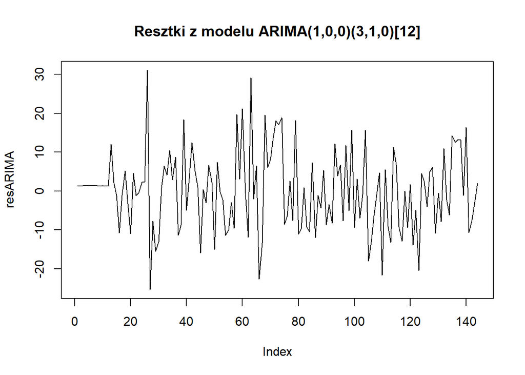

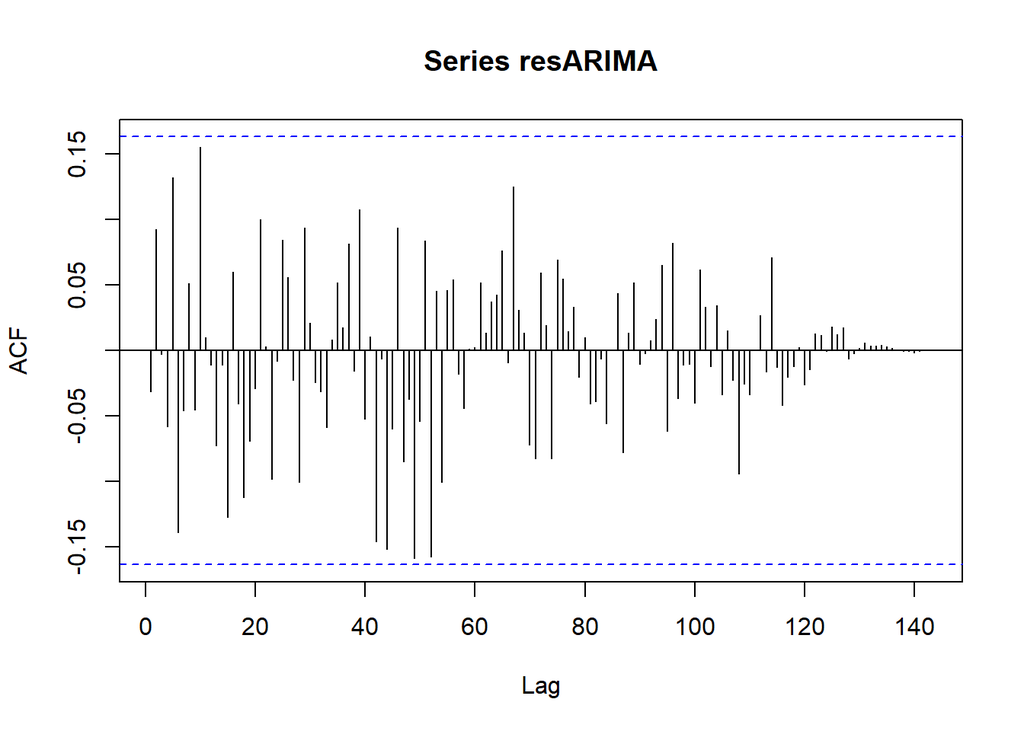

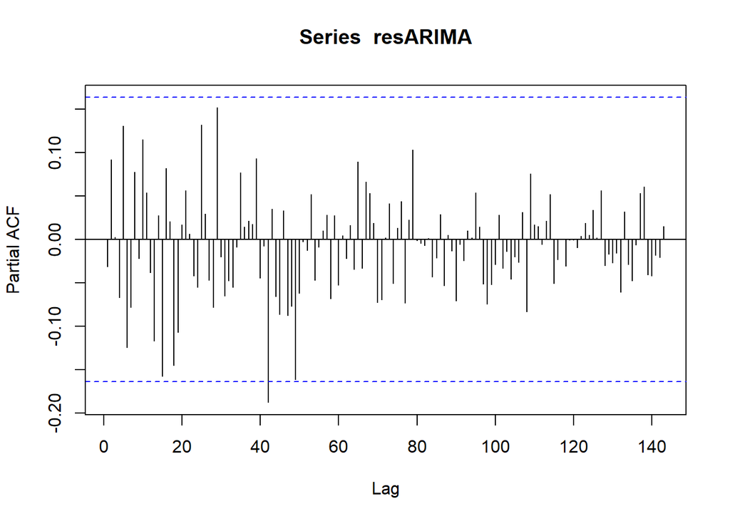

```
##
##  Box-Pierce test
##
## data:  resARIMA
## X-squared = 0.14269, df = 1, p-value = 0.7056
```

Otrzymaliśmy biały szum, zatem możemy przejśc do predykcji. Postąpimy analogicznie jak w przypadku reszt. Do wydobycia informacji na temat dopasowania uzyskanej predykcji posłużymy się funkcją accuracy().

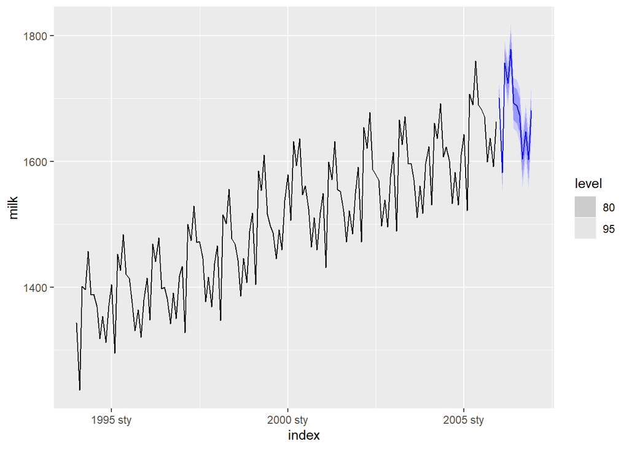

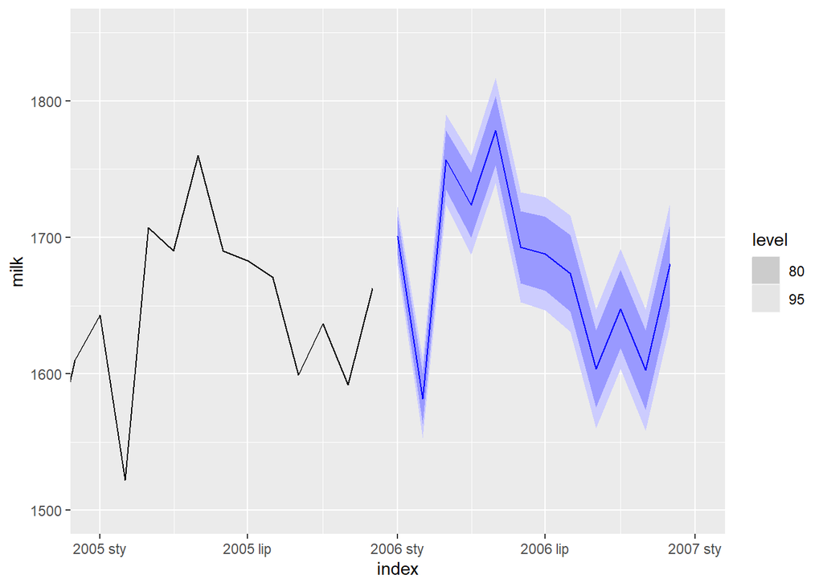

```
## # A tibble: 1 x 10
##   .model             .type     ME  RMSE   MAE      MPE  MAPE  MASE RMSSE    ACF1
##   <chr>              <chr>  <dbl> <dbl> <dbl>    <dbl> <dbl> <dbl> <dbl>   <dbl>
## 1 "ARIMA(value ~ pd~ Trai~ 0.0220  10.3  8.01 -0.00202 0.531 0.258 0.275 -0.0315
```

Widzimy, że wystąpiła znaczna poprawa wskaźników predykcji, w przypdaku modelu utworzonego z całych danych.

Dodatkowo, możemy wyciągnąć wartości prognozy poprzez użycie funkcji hilo().

```
## # A tsibble: 12 x 6 [1M]
## # Key:       .model [1]
##    .model                        index        value .mean                  `80%`
##    <chr>                         <mth>       <dist> <dbl>                 <hilo>
##  1 "ARIMA(value ~ pdq(p = 0:~ 2006 sty N(1701, 119) 1701. [1687.009, 1715.024]80
##  2 "ARIMA(value ~ pdq(p = 0:~ 2006 lut N(1582, 213) 1582. [1563.135, 1600.536]80
##  3 "ARIMA(value ~ pdq(p = 0:~ 2006 mar N(1757, 286) 1757. [1735.015, 1778.365]80
##  4 "ARIMA(value ~ pdq(p = 0:~ 2006 kwi N(1724, 343) 1724. [1700.067, 1747.555]80
##  5 "ARIMA(value ~ pdq(p = 0:~ 2006 maj N(1778, 388) 1778. [1753.041, 1803.529]80
##  6 "ARIMA(value ~ pdq(p = 0:~ 2006 cze N(1693, 423) 1693. [1666.352, 1719.070]80
##  7 "ARIMA(value ~ pdq(p = 0:~ 2006 lip N(1688, 450) 1688. [1660.864, 1715.262]80
##  8 "ARIMA(value ~ pdq(p = 0:~ 2006 sie N(1674, 472) 1674. [1645.909, 1701.586]80
##  9 "ARIMA(value ~ pdq(p = 0:~ 2006 wrz N(1604, 489) 1604. [1575.419, 1632.076]80
## 10 "ARIMA(value ~ pdq(p = 0:~ 2006 paź N(1648, 502) 1648. [1618.833, 1676.246]80
## 11 "ARIMA(value ~ pdq(p = 0:~ 2006 lis N(1603, 512) 1603. [1573.839, 1631.837]80
## 12 "ARIMA(value ~ pdq(p = 0:~ 2006 gru N(1681, 520) 1681. [1651.536, 1709.987]80
## # ... with 1 more variable: 95% <hilo>
```

Ponieważ dla pakietu “itsmr” obliczyliśmy dodatkowo wskaźniki predykcji, uprzednio dzieląc model i porównując wynik z oryginalnymi danym, zatem tutaj postąpimy analogicznie.

```
## Wskazujemy dobrane parametry, takie jakie funkcja dobrała dla pełnych danych i otrzymujemy model:
```

```
## Series: value
## Model: ARIMA(1,0,0)(3,1,0)[12] w/ drift
##
## Coefficients:
##          ar1     sar1     sar2     sar3  constant
##       0.8816  -0.8660  -0.7625  -0.5901    9.6491
## s.e.  0.0456   0.0774   0.0840   0.0743    1.0580
##
## sigma^2 estimated as 121.3:  log likelihood=-467.14
## AIC=946.27   AICc=947.02   BIC=963
```

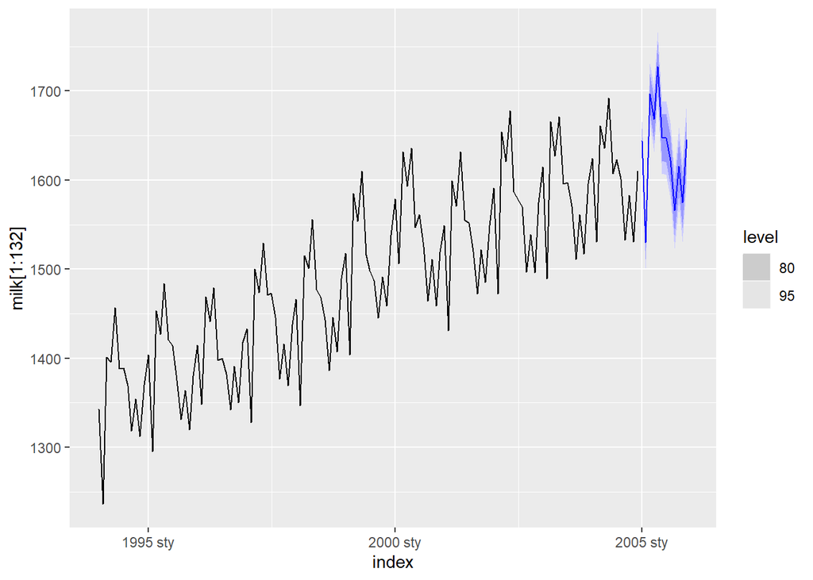

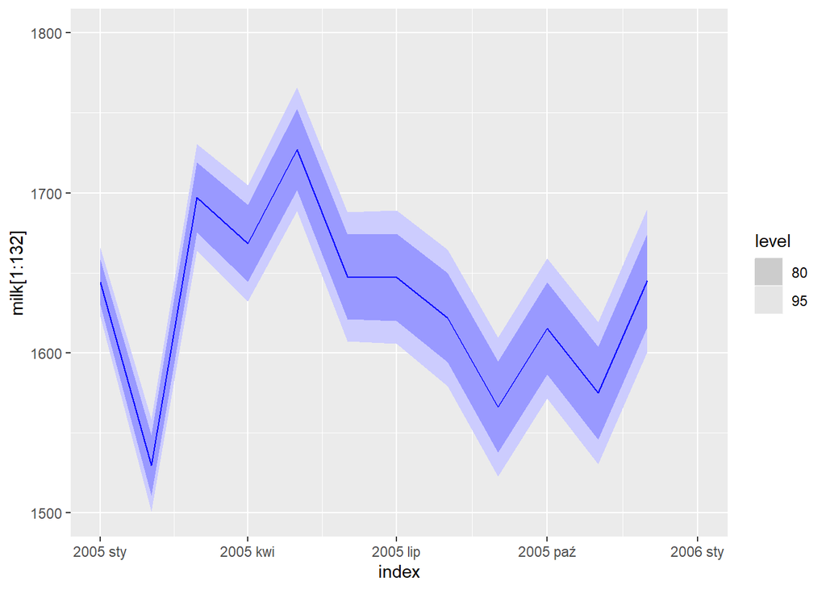

```
## # A tibble: 1 x 10
##   .model              .type     ME  RMSE   MAE     MPE  MAPE  MASE RMSSE    ACF1
##   <chr>               <chr>  <dbl> <dbl> <dbl>   <dbl> <dbl> <dbl> <dbl>   <dbl>
## 1 "ARIMA(value ~ pdq~ Trai~ 0.0293  10.3  7.97 0.00146 0.533 0.277 0.296 -0.0372
```

### Wykorzystanie pakietu “bsts”

Wychodząc naprzeciw modelowi ARIMA, który jest rozszerzeniem modelu ARMA, wykorzystamy zupełnie inne podejście do prognozowania, mianowicie wykorzystamy Bayesowski strukturalny model szeregów czasowych. W tym celu wykorzystamy bibliotekę “bsts”. Swoje poczynania opierałem o artykuł twórców tej bilbioteki (https://www.unofficialgoogledatascience.com/2017/07/fitting-bayesian-structural-time-series.html).

#### Generalny opis

Model składa się z trzech głównych elementów:

1. Filtru Kalmana- technika dekompozycji szeregów czasowych. W tym kroku badacz może dodać różne zmienne stanu: trend, sezonowość, regresję i inne.
2. Metoda spike-and-slab- w tym kroku wybierane są najważniejsze predyktory regresji. Bayesowskie uśrednianie modeli. Łączenie wyników i obliczanie predykcji.
3. Model może być użyty do odkrycia związków przyczynowych z jego kontrfaktyczną predykcją i obserwowanymi danymi.

Możliwą wadą modelu może być jego stosunkowo skomplikowane podłoże matematyczne i trudna implementacja w postaci programu komputerowego. Jednak język programowania R posiada gotowe do użycia pakiety do obliczania modelu BSTS, które nie wymagają od badacza silnego zaplecza matematycznego. Paradoksalnie może być bardziej przejrzysta niż modele ARIMA. Jest ona bardziej przejrzysta, ponieważ jej reprezentacja nie opiera się na różnicach, opóźnieniach i średnich ruchomych. Można wizualnie sprawdzić podstawowe komponenty modelu. Model ten lepiej radzi sobie z niepewnością, ponieważ można określić niepewność następczą poszczególnych składowych, kontrolować wariancję składowych i narzucić wcześniejsze przekonania na model. Wreszcie, co nie mniej ważne, każdy model ARIMA może być przekształcony jako model strukturalny.

#### Bayesowski strukturalny model szeregu czasowego

Strukturalny model szeregów czasowych jest zdefiniowany przez dwa równania. Równanie obserwacji odnosi obserwowane dane $y_t$ do wektora zmiennych ukrytych $\alpha_t$ zwanych “stanem”. Stąd
$$y_t=Z^T_t\alpha_t+\epsilon_t$$
Równanie przejścia opisuje, w jaki sposób stan utajony zmienia się w czasie.
$$\alpha_{t+1}=T_t\alpha_t+R_t\eta_t$$
Składowe błędu $\epsilon_t$ i $\eta_t$ są gaussowskie i niezależne od wszystkiego innego. Tablice $Z_t$ , $T_t$ i $R_t$ są parametrami strukturalnymi. Mogą one zawierać parametry w sensie statystycznym, ale często zawierają po prostu strategicznie rozmieszczone zer i jedynek wskazujące, które bity $\alpha_t$ są istotne dla danego obliczenia.

Najprostszym użytecznym modelem jest “model poziomu lokalnego”, w którym wektor $\alpha_t$ jest po prostu skalarem $\mu_t$. Model poziomu lokalnego to losowy spacer obserwowany w szumie
$$y_t = \mu_t + \epsilon_t$$
$$\mu_{t+1} = \mu_t + \eta_t$$
Tutaj $\alpha_t = \mu_t$, a $Z_t$, $T_t$ i $R_t$ mają wartość skalarną 1. Podobnie jak hierarchiczne modele Bayesa dla danych zagnieżdżonych, model poziomu lokalnego jest kompromisem pomiędzy dwoma skrajnościami. Kompromis ten jest określony przez wariancje $\epsilon_t \sim N(0, \sigma^2)$ i $\eta_t \sim N(0,\tau^2)$. Jeżeli $\tau^2 = 0$ to $\mu_t$ jest stałą, więc dane są szumem gaussowskim i.i.d. . W takim przypadku najlepszym estymatorem $y_{t+1}$ jest średnia z $y_1, \dots, y_t$ i odwrotnie, jeśli $\sigma^2=0$ to dane są losowe, w tym przypadku najlepszym estymatorem $y_{t+1}$ jest $y_t$.

Przejdźmy do utworzenia modelu dla danych “milk”. W przypadku tworzenia modelu ARIMA, należało przekonwertować dane do postaci tabeli “tsibble”. W tym przypadku, musimy przygotowac dane poprzez przekształcenie ich do postaci tabeli “zoo”. W tym celu wykorzystamy funkcję as.zoo() z bilbioteki “zoo”.

```
##          milk
## sty 1994 1343
## lut 1994 1236
## mar 1994 1401
## kwi 1994 1396
## maj 1994 1457
## cze 1994 1388
## lip 1994 1389
## sie 1994 1369
## wrz 1994 1318
## paź 1994 1354
## lis 1994 1312
## gru 1994 1370
## sty 1995 1404
## lut 1995 1295
## mar 1995 1453
## kwi 1995 1427
## maj 1995 1484
## cze 1995 1421
```

Działanie tej metody wymaga utworzenia listy do której dodajemy kolejne modele takie jak trend, sezonowość, zmienne zewnętrzne.

```r
ss <- list()
ss <- AddLocalLinearTrend(ss, milkzoo$milk)
ss <- AddSeasonal(ss, milkzoo$milk, nseasons = 12, season.duration = 1)
```

Do obliczenia rozkładu naszego szeregu, pakiet “bsts” wykorzystuje algorytm Gibbs’a (Gibbs sampling). W statystyce próbkowanie Gibbsa lub próbnik Gibbsa jest algorytmem łańcucha Markowa Monte Carlo (MCMC) służącym do uzyskiwania sekwencji obserwacji, które są aproksymowane z określonego wielowymiarowego rozkładu prawdopodobieństwa, gdy bezpośrednie próbkowanie jest trudne. Sekwencja ta może być wykorzystana do aproksymacji wspólnego rozkładu (np. do wygenerowania histogramu rozkładu); do aproksymacji rozkładu krańcowego jednej ze zmiennych lub pewnego podzbioru zmiennych (np. nieznanych parametrów lub zmiennych ukrytych); lub do obliczenia całki (np. wartości oczekiwanej jednej ze zmiennych).

```r
model1 <- bsts(milkzoo$milk,
               state.specification = ss,
               niter = 1e3)
```

[output not shown]

Sprwadźmy jakie komponenty ma nasz model. Możemy spróbować ręcznie wyciągnąć składniki.

```r
trend <- model1$state.contributions[,"trend",] %>% as.table() %>% as.data.frame() %>% dplyr::select(Freq)
sezon <- model1$state.contributions[,"seasonal.12.1",] %>% as.table() %>% as.data.frame() %>% dplyr::select(Freq)
```

Natomiast pojawia się pewien problem. Ponieważ dokonaliśmy 1000-krotnej iteracji, aby otrzymać rozkład naszego szeregu, zatem ilość składników trendu oraz sezonowości będą 1000-krotnie powiększona.

```
## Liczba składników trendu:       144000
```

```
## Liczba składników sezonowości:  144000
```

W celu graficznej analizy modelu jak i jego składników, twórcy biblioteki “bsts” utworzyli funkcje plot.bst(), która w prosty sposób pozwala zwizualizowac otrzymane rezultaty jak i przyszłe predykcje.

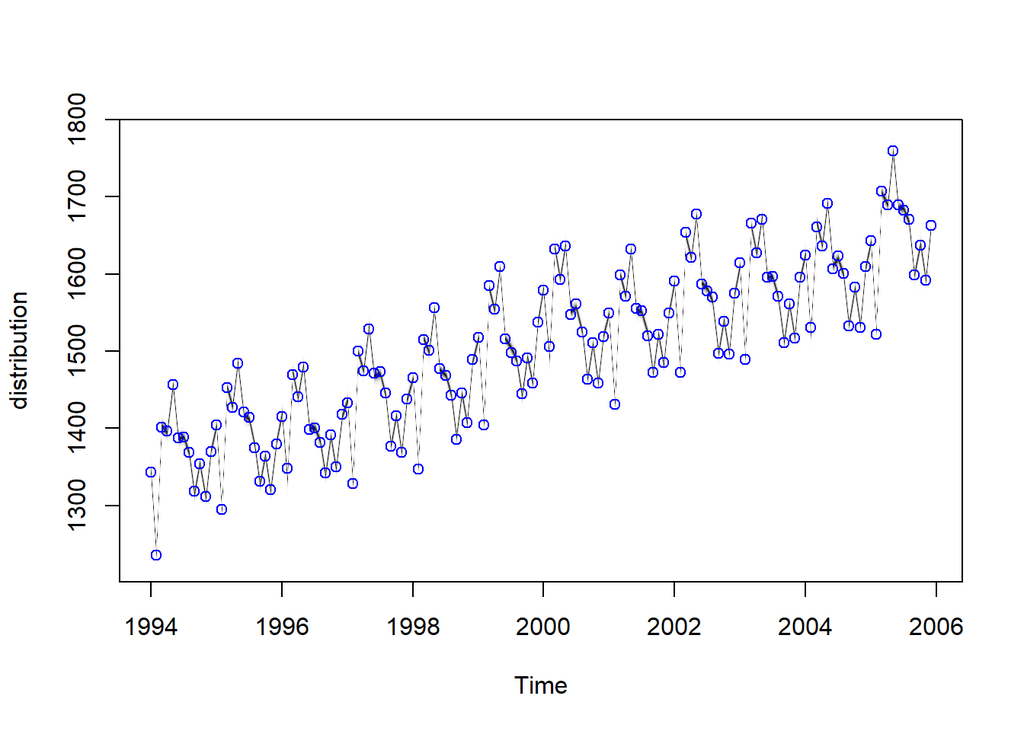

Niebiskie punkty odpowiadają zaobserwowanym danym, natomiast ciemny zarys odpowiada dobranemu rozkładowi.

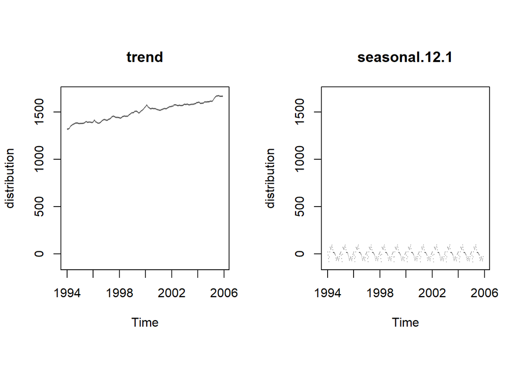

Aby sprawdzić wszystkie możliwe wizualizacje, należy skorzystać z formuły: plot(‘nazwa modelu’, “help”). Przejdźmy do predykcji.

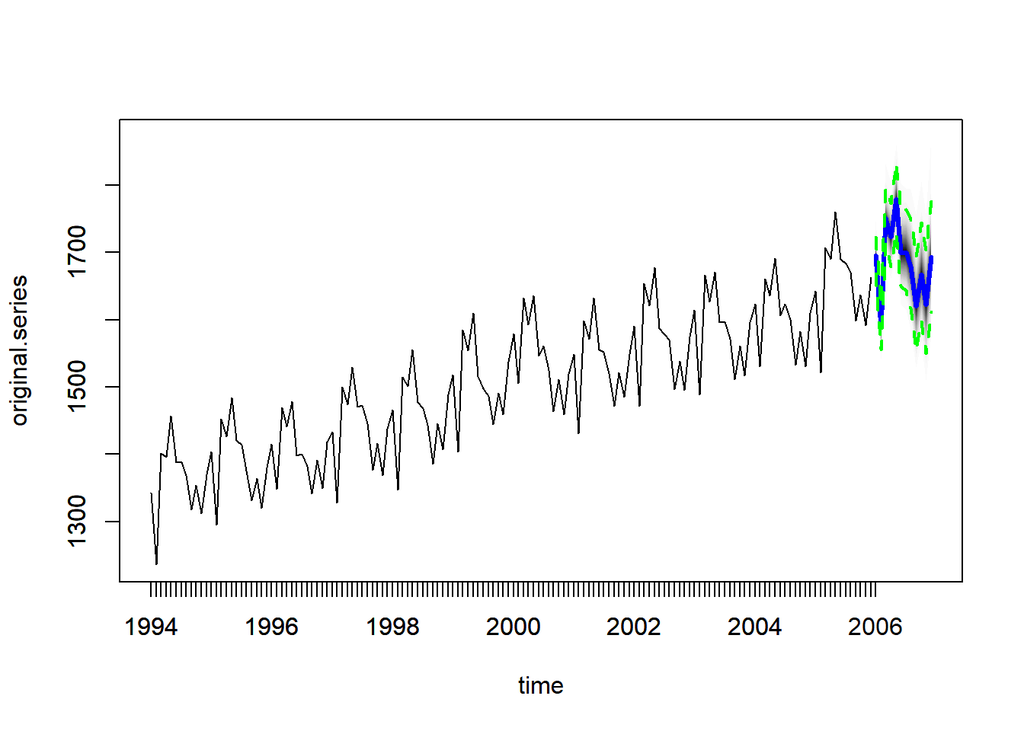

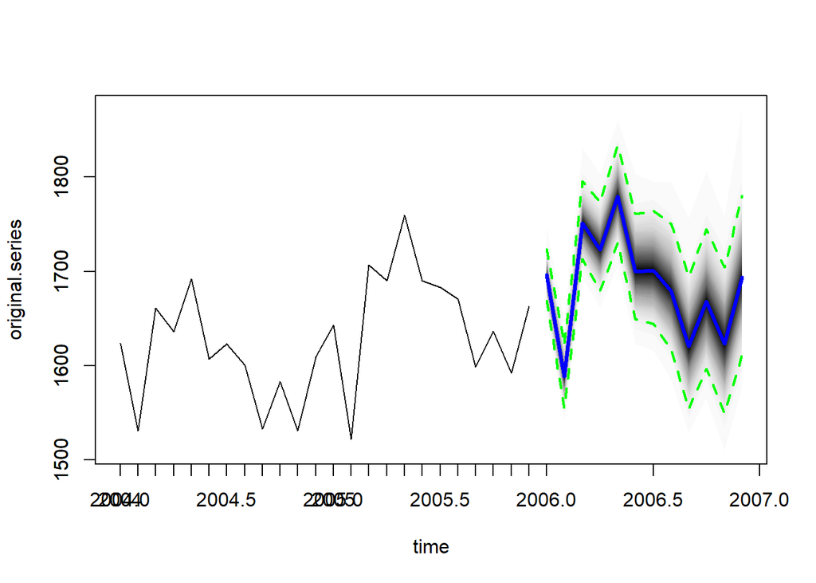

Składniki dopasowania predykcji uzyskamy ręcznie poprzez podzielenie danych na część treningową i testową.

[output not shown]

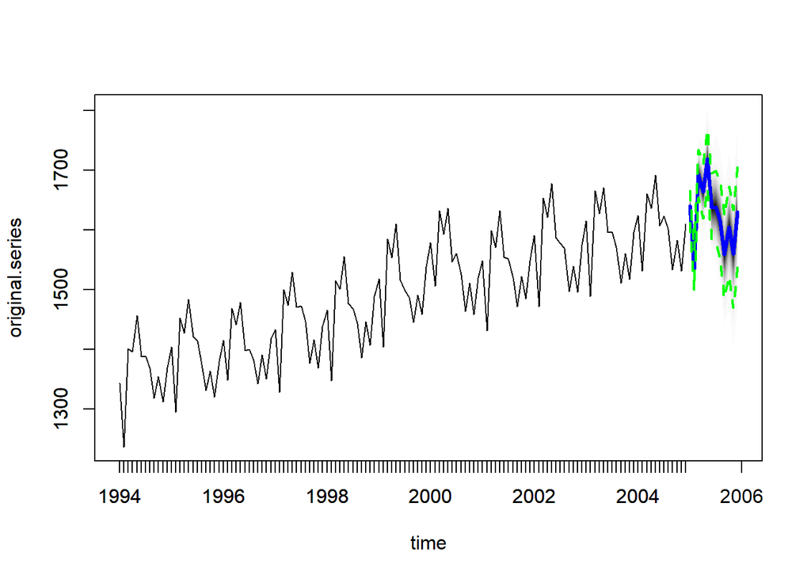

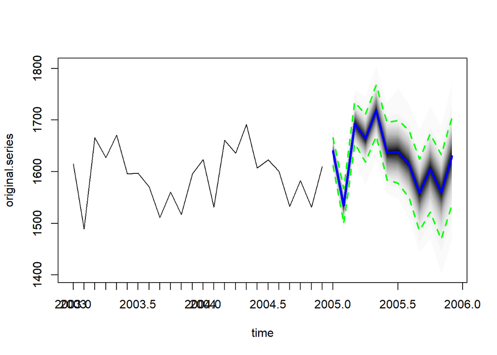

```
## ME:     30.32546
```

```
## MSE:    1288.509
```

```
## RMSE:   35.89581
```

```
## MAE:    32.37834
```

[output not shown]

```
## MAPE:   1.947945
```

```
## MASE:   1.123923
```

```
## RMSSE:  1.031985
```

### Finalne porównanie

```
## Wskaźnik:          ARMA(itsmr):          ARIMA(fpp3):          BSTS(bsts):
```

```
## ME                 32.69889              0.02934747            30.32546
```

```
## MSE                1527.017              105.6856              1288.509
```

```
## RMSE               39.07706              10.28035              35.89581
```

```
## MAE                35.07983              7.97131               32.37834
```

```
## MPE                2.111872              0.001457436           1.947945
```

```
## MAPE               2.111872              0.5326365             1.947945
```

```
## MASE               1.217697              0.2767015             1.123923
```

```
## RMSSE              1.123444              0.2955545             1.031985
```

Finalne porównanie wizualne.

[figure not shown]

### Dodatek - Prophet

**Kliknij, aby rozwinąć**

Biblioteka “prophet” został utworzony przez grupę data scientist-ów z zespołu Facebook-a. Prophet jest procedurą prognozowania danych szeregów czasowych opartą na modelu addytywnym, w którym nieliniowe trendy są dopasowywane do rocznej, tygodniowej i dziennej oraz tkz. efekty wakacyjne (holiday effects). Najlepiej sprawdza się w przypadku szeregów czasowych, które mają silne efekty sezonowe i kilka sezonów danych historycznych. Prophet jest odporny na brak danych i przesunięcia w trendzie i zazwyczaj dobrze radzi sobie z wartościami odstającymi. Jest to procedura wysoce zautomatyzowana i radząca sobie z wieloma typowymi problemami związanymi z utworzeniem odpowiedniego modelu, przy tym jest też bardzo przystępnie skonstruowana.

Z uwagi, że jest to bardzo rozległa metoda, dlatego chciałem ją wprowadzić jako dodatek. Dodatkową jej zaletą jest jej ogromna plastyczności i przejrzystość.

#### Budowa modelu

Skonstruujmy model dla naszych danych ze zbioru “milk”.

Zaczniemy od odpowiedniego przygotowania formatu tabeli. Funkcja prophet() wymaga od nas tabeli typu data.frame() wraz ze wskazaniem kolumny dat oznaczonej jako “ds” oraz kolumny wartości oznaczonej jako “y”. W tym celu sztucznie wygenerujemy kolumnę dat i połączymy z wartościami ze zbioru “milk”.

```
##  [1] "1994-01-01" "1994-02-01" "1994-03-01" "1994-04-01" "1994-05-01"
##  [6] "1994-06-01" "1994-07-01" "1994-08-01" "1994-09-01" "1994-10-01"
## [11] "1994-11-01" "1994-12-01" "1995-01-01" "1995-02-01" "1995-03-01"
## [16] "1995-04-01" "1995-05-01" "1995-06-01"
```

```
##            ds    y
## 1  1994-01-01 1343
## 2  1994-02-01 1236
## 3  1994-03-01 1401
## 4  1994-04-01 1396
## 5  1994-05-01 1457
## 6  1994-06-01 1388
## 7  1994-07-01 1389
## 8  1994-08-01 1369
## 9  1994-09-01 1318
## 10 1994-10-01 1354
## 11 1994-11-01 1312
## 12 1994-12-01 1370
## 13 1995-01-01 1404
## 14 1995-02-01 1295
## 15 1995-03-01 1453
## 16 1995-04-01 1427
## 17 1995-05-01 1484
## 18 1995-06-01 1421
```

Nastepnie użyjemy standardowej procedury tworzenia modelu i jego przewidywania. Tutaj należy uważać na dobieranie parametrów. Mimo, że można użyć funkcji prophet() do dopasowania danych miesięcznych, to model bazowy jest ciągły (dziennie). Oznacza to, że możemy otrzymać dziwnie zachowujące się wyniki, jeśli dopasujemy model do danych miesięcznych, a następnie wygenerujemy prognozy dzienne.

```r
m <- prophet(df, yearly.seasonality = T, weekly.seasonality=T, daily.seasonality=T)
future <- make_future_dataframe(m, periods = 12, freq="month")
forecastProph <- predict(m, future)
tail(forecastProph[c('ds', 'yhat', 'yhat_lower', 'yhat_upper')], 12)
```

```
##             ds     yhat yhat_lower yhat_upper
## 145 2006-01-01 1688.798   1671.837   1704.170
## 146 2006-02-01 1580.231   1562.951   1597.609
## 147 2006-03-01 1742.980   1726.516   1760.971
## 148 2006-04-01 1719.426   1701.971   1736.098
## 149 2006-05-01 1775.328   1758.260   1794.023
## 150 2006-06-01 1700.509   1682.702   1718.985
## 151 2006-07-01 1698.219   1679.471   1715.298
## 152 2006-08-01 1675.301   1657.467   1692.246
## 153 2006-09-01 1621.825   1603.325   1638.895
## 154 2006-10-01 1662.930   1644.018   1680.880
## 155 2006-11-01 1621.531   1603.821   1639.104
## 156 2006-12-01 1694.003   1673.899   1712.686
```

Z powyższego otrzymaliśmy gotowy model wraz z wykresami jego komponentów ()

```
## Uwaga: Jeżeli drugi wykres się nie pojawia, należy 'przeklikać' okno przeglądarki.
```

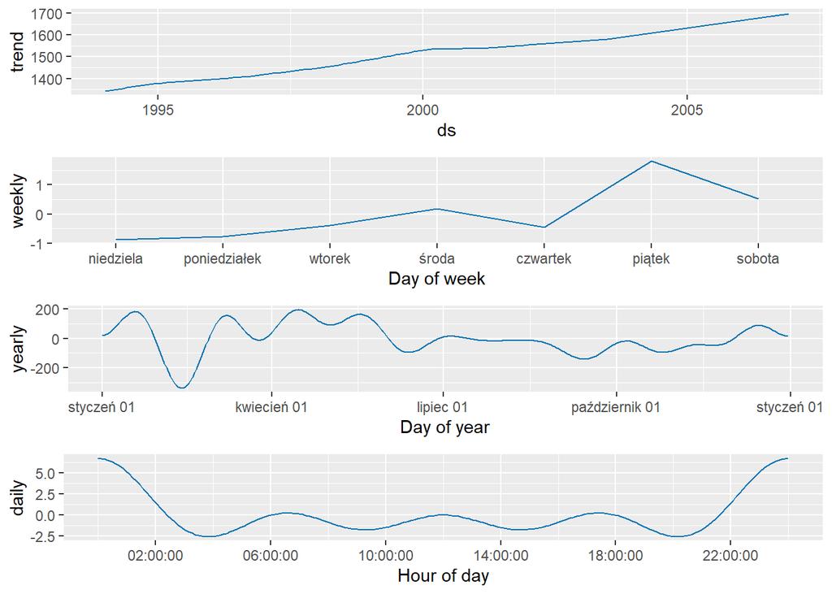

[interactive chart not shown]

#### Finalne porównanie (+dodatek)

```
## Wskaźnik:          ARMA(itsmr):          ARIMA(fpp3):          BSTS(bsts):          Prophet(prophet):
```

```
## ME                 32.69889              0.02934747            30.32546             36.65606
```

```
## MSE                1527.017              105.6856              1288.509             1717.588
```

```
## RMSE               39.07706              10.28035              35.89581             41.4438
```

```
## MAE                35.07983              7.97131               32.37834             36.65606
```

```
## MPE                2.111872              0.001457436           1.947945             2.202232
```

```
## MAPE               2.111872              0.5326365             1.947945             2.202232
```

```
## MASE               1.217697              0.2767015             1.123923             1.272412
```

```
## RMSSE              1.123444              0.2955545             1.031985             1.191487
```

[figure not shown]

#### Podsumowanie

**Kliknij, aby rozwinąć**

Nie każdy pakiet w swoich metodach podaje jawnie wartości dopasowania modelu. Natomiast udało nam się, z każdej zaproponowanej metody, wyciągnąć dopasowanie predykcji, poprzez podział zbioru na treningowy oraz testowy.

W przypadku modelu ARMA z pakietu itsmr, uzyskał on porównywalne wyniki z pakietami wysoce zautomatyzowanymi i powszechnymi.

Warto podkreślić, że badane dane, były średnimi miesięcznymi. W takim przypadku, pakiety “bsts” oraz “prophet”, które skupiają się bardziej na szeregach z danych dziennych, w swojej “domyślnej” konfiguracji, sprawują się wyraźnie gorzej niż byśmy sobie tego życzyli.

Zapewne istnieją sposoby lepszego dopasowania tych dwóch metod poprzez dodanie odpowiednich zmiennych do funkcji, natomiast wydaje się, że prostszym rozwiązaniem jest utworzenie modelu ARIMA.

Finalny wniosek jest następujący: W pierwszej kolejności należy zapoznać się z danymi i wstępnie określić jaki model będzie wykazywał najlepsze dopasowanie i predykcję (w zależności jakie wbudowane algorytmy on stosuje). W tym celu, ręczna dekompozycja, jest jak najbardziej wskazana. Po utworzeniu modelu i uzyskaniu zadowalającego dopasowania (wraz z predykcją), możemy przejść do kontrprzykładów z wykorzystaniem innych modeli. Dodatkowo możemy starać się poprawić zachowanie naszego modelu poprzez przekształcenie danych z wykorzystaniem np. logarytmu lub metody Box’a Cox’a, czy też odpowiednie w pakietach funkcję. Finalne porównanie metod powinno odbywać się w opraciu o modele o różnych podejściach do problemu oraz o dodatkową wiedzę ekspercką.